# SCENIC step 4: GRN-based cell states (cell clustering)

#### Abstract

Final step of SCENIC workflow: Identifying cell states based on the gene regulatory network activity.

#### Package version: SCENIC 0.1.1

# Contents

> The code from this file is included in the `runSCENIC()` function. It is not required to run it separatelly. This tutorial assumes you have read the introduction to SCENIC and run the previous steps: `vignette(package="SCENIC")`.

# Step 4. Identifying stable cell states based on the gene-regulatory network activity

The main outputs of SCENIC are the gene regulatory network (in the form of regulons) and the activity of this network in the cells. Furthermore, the final step of SCENIC is to identify cell clusters and stable cell states based on the gene regulatory network activity. A simple way to identify these states is performing a clustering on the regulon activity matrix (either binary or the AUC values), which will reveal the network states that are recurrent across multiple cells. In this way, these states are equivalent to the *attractor states* of the network.

In this tutorial we present a few examples using t-SNE on the binary matrix, but any other clustering method could be used (e.g. see the binary matrix heatmap from Step 3.2, and t-SNE on the AUC matrix from Step 3.1). If the binary matrix is used, the resulting clustering tends to reduce batch-effects and highlight higher-order similarities, on the other hand, the clustering on the AUC matrix might provide more details.

## Load cell info and binary activity matrix

```r
load("data/esetMouseBrain.RData")
exprMat <- exprs(esetMouseBrain)
load("data/colVars.RData")
cellInfo <- pData(esetMouseBrain)[, names(colVars), drop=F]

load("int/cellColorNgenes.RData")
load("int/3.7_binaryRegulonActivity_nonDupl.RData")
tBinaryAct <- t(binaryRegulonActivity_nonDupl)
```

## Calculate t-SNE on the binary regulon activity

A t-SNE based on the AUC regulon activity was created on *Step 3* (see file `output/Step3.1_AUCtSNEs.pdf`). Here we will plot the t-SNE based on the binary regulon activity. Since the t-SNEs can vary depending on the parameters chosen, such as the perplexity and the distance used, we will plot several options. We recommend you to explore the results and try different parameters if needed.

Note that with the binary activity matrix, it is quite likely that some cells show exactly the same combination of active regulons. This should be taken into account when applying the clustering. All these cells will have distance zero and might be collapsed into a single point (depending on the clustering method). To prefent this effect, we will add some jitter to the PCA-based t-SNE.

> Briefly, a t-SNE is a 2D projection of the cells, where cells (dots) are placed close to each other if they have similar input profiles (in this case, similar GRN activity according to the binary regulon activity matrix).

```r
library(Rtsne)

##################################
# PCA based t-SNE
set.seed(123)
tBinaryAct_jitter <- jitter(tBinaryAct, factor=1)
tsneBinaryActivity_PCA <- Rtsne(tBinaryAct_jitter, initial_dims=5, perplexity=30)
rownames(tsneBinaryActivity_PCA$Y) <- rownames(tBinaryAct_jitter)
colnames(tsneBinaryActivity_PCA$Y) <- c("tsne2", "tsne1")
tsneBinaryActivity_PCA$Y <- tsneBinaryActivity_PCA$Y[,c("tsne1", "tsne2")]
save(tsneBinaryActivity_PCA, file="int/4.1_tsneBinaryActivity_5PC.RData")

##################################
# PCA based t-SNE
set.seed(123)
tBinaryAct_jitter <- jitter(tBinaryAct, factor=1)
tsneBinaryActivity_PCA <- Rtsne(tBinaryAct_jitter, initial_dims=50, perplexity=30)
rownames(tsneBinaryActivity_PCA$Y) <- rownames(tBinaryAct_jitter)
colnames(tsneBinaryActivity_PCA$Y) <- c("tsne2", "tsne1")
tsneBinaryActivity_PCA$Y <- tsneBinaryActivity_PCA$Y[,c("tsne1", "tsne2")]
save(tsneBinaryActivity_PCA, file="int/4.1_tsneBinaryActivity_50PC.RData")

##################################
# Distance-based t-SNE
corDist <- as.dist(1-cor(t(tBinaryAct)))
set.seed(123)
tsneBinaryActivity_Dist <- Rtsne(corDist, is_distance=TRUE, perplexity=30)
rownames(tsneBinaryActivity_Dist$Y) <- labels(corDist)
colnames(tsneBinaryActivity_Dist$Y) <- c("tsne1", "tsne2")
save(tsneBinaryActivity_Dist, file="int/4.1_tsneBinaryActivity_Dist.RData")
```

## Plot t-SNEs

### Coloured by cell properties

We will now plot the different versionf of the t-SNE coloured by the known cell properties. These plots might help interprete the resulting t-SNE and identify the best set of parameters (e.g. number of PCs, perplexity…). On the next section, we will project the regulon activities on the chosen t-SNE, to explore their relationship with the gene regulatory network activity.

To detect the most likely stable states, we can also generate a density plot. The areas with higher density are more likely to correspond to ‘stable states’.

```r
tSNEs_binary <- list()
load("int/4.1_tsneBinaryActivity_Dist.RData")
tSNEs_binary[["Dist"]] <- tsneBinaryActivity_Dist$Y
load("int/4.1_tsneBinaryActivity_5PC.RData")
tSNEs_binary[["5PC"]] <- tsneBinaryActivity_PCA$Y
load("int/4.1_tsneBinaryActivity_50PC.RData")
tSNEs_binary[["50PC"]] <- tsneBinaryActivity_PCA$Y

for(tsneName in names(tSNEs_binary))
{
    tSNE_binary <- tSNEs_binary[[tsneName]]

    # Density
    library(KernSmooth)
    library(RColorBrewer)
    dens2d <- bkde2D(tSNE_binary, 1)$fhat

    Cairo::CairoPDF(paste0("output/Step4.1_tsneModuleActivity_",tsneName,".pdf"), width=15, height=5)
    par(mfrow=c(1,3))
    # nGenes
    plot(tSNE_binary, col=cellColorNgenes[rownames(tSNE_binary)], pch=16)
    # density
    image(dens2d, col=brewer.pal(9, "YlOrBr"), axes=FALSE)
    contour(dens2d, add=TRUE, nlevels=5, drawlabels=FALSE)

    # Known phenotype:
    if(!is.null(cellInfo))
    {
        nVars <- ncol(cellInfo)
        for(varName in colnames(cellInfo))
        {
            cellColor <- setNames(colVars[[varName]][as.character(cellInfo[,varName])],
                                  rownames(cellInfo))
            plot(tSNE_binary, col=cellColor[rownames(tSNE_binary)], pch=16,
                 main=varName, sub="t-SNE on Binary regulon activity",
                 xlab="", ylab="",axes = FALSE)
        }
    }
    # legend(10, 25, names(colVars[[varName]]), fill=colVars[[varName]], cex=.7, bty="n")
    for(i in seq_len(3 - ((nVars+2) %% 3))) # fill remaining slots in page
    {
        plot.new()
    }
    dev.off()
}
```

```
## Copyright M. P. Wand 1997-2009
```

> *preview, only for the HTML tutorial:*

t-SNE based on binary activity (and density), coloured by cell properties

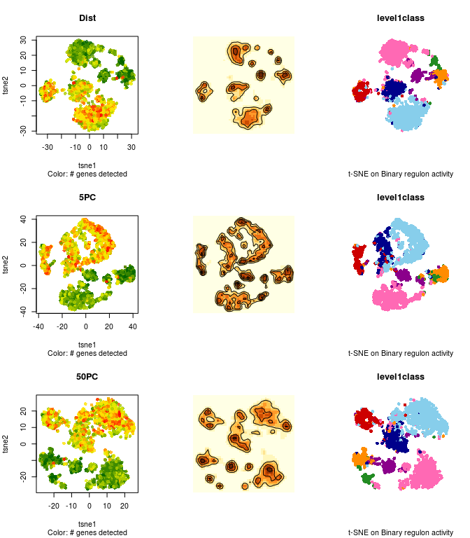

### Coloured by regulon activity

Finally, we can choose one of the t-SNEs and project on it the activity of the regulons.

Here we provide several options:

```r
# Choose a t-SNE
load("int/4.1_tsneBinaryActivity_50PC.RData")
tSNE_binary <- tsneBinaryActivity_PCA$Y
tSNEname <- "tsneBinaryActivity_50PC"

# Load...
load("int/3.6_binaryRegulonActivity.RData")
load("int/3.9_binaryRegulonOrder.RData")
load("int/3.2_regulonAUC.RData")
load("int/3.4_AUCellThresholds.RData")
```

```r
regOrder<- binaryRegulonOrder[which(binaryRegulonOrder %in% rownames(tBinaryAct))]
Cairo::CairoPDF(paste0("output/Step4.2_",tSNEname,"_BinaryRegulons.pdf"), width=20, height=15)
par(mfrow=c(4,6))
cells_trhAssignment <- plot_aucTsne(tSNE=tSNE_binary, exprMat=exprMat,
    regulonAUC=t(tBinaryAct)[binaryRegulonOrder,], cex=1.5, plots="binary", thresholds=0)
dev.off()

regOrder<- binaryRegulonOrder[which(binaryRegulonOrder %in% rownames(regulonAUC))]
Cairo::CairoPDF(paste0("output/Step4.2_",tSNEname,"_AUCRegulons.pdf"), width=20, height=15)
par(mfrow=c(4,6))
cells_trhAssignment <- plot_aucTsne(tSNE=tSNE_binary, exprMat=exprMat,
    regulonAUC=regulonAUC[regOrder,], cex=1.5, plots="AUC", thresholds=0)
dev.off()

Cairo::CairoPDF(paste0("output/Step4.2_",tSNEname,"_allPlots.pdf"), width=20, height=5)
par(mfrow=c(1,4))
cells_trhAssignment <- plot_aucTsne(tSNE=tSNE_binary, exprMat=exprMat,
        regulonAUC=regulonAUC[regOrder,],
        alphaOff=0.1, thresholds=cells_AUCellThresholds[regOrder])
dev.off()
```

> *preview, only for the HTML tutorial:*

t-SNE based on binary activity, coloured by regulon activity (AUC)

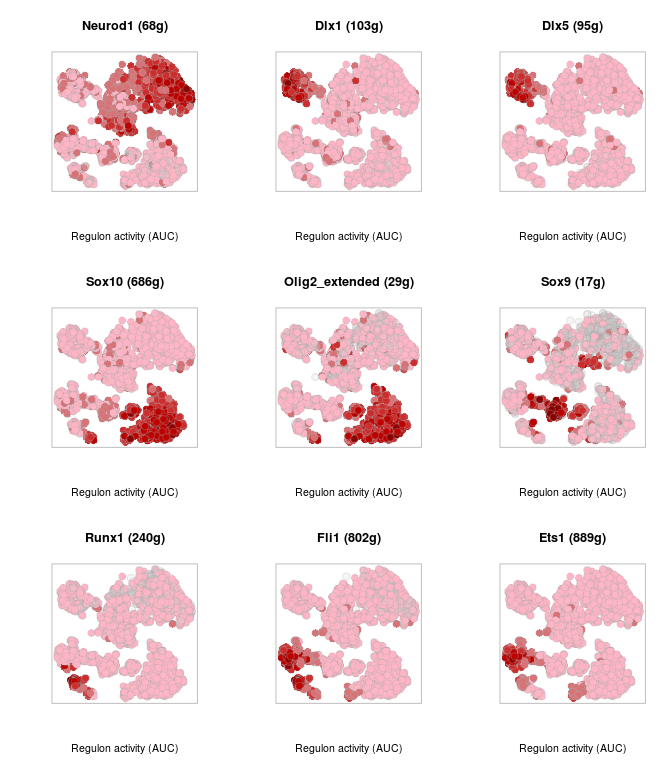

# SessionInfo

```r
date()
```

```
## [1] "Fri Jun  9 11:04:40 2017"
```